# Finding Happiness

## Final Plots and Summary

#### Plot One

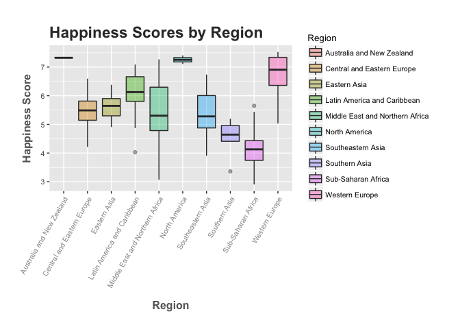

When grouped by regions, the gap between the happy and unhappy countries are evident. Middle Eastern and Norther African countries have big variances.

#### Plot Two

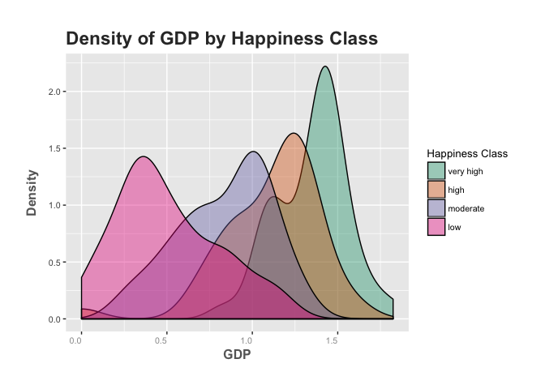

GDP shows the biggest difference in happiness out of all factors. The happiest group sticks out in the crowd of GDP, and the shift of the groups is clear in that factor as well. As the GDP number increases, the happier the people.

#### Plot Three

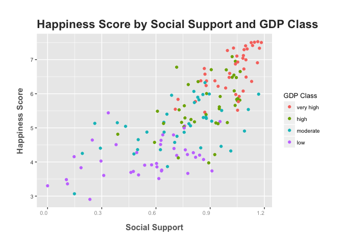

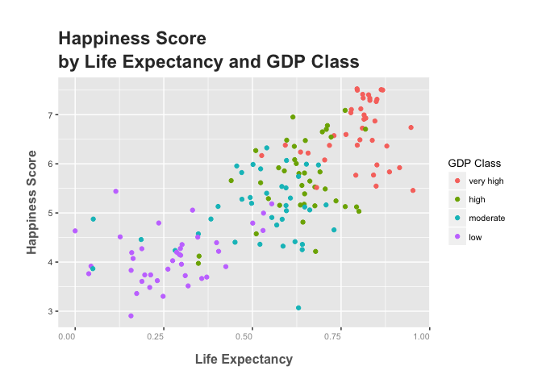

Positive (and stronger than other factors) correlations in both plots indicating as the GDP class goes higher, more social support people have, their life expectancy increases, and happier they are.

## Reflection

I first assumed that happiness is affected mostly by social support and life expectancy. I’ve also thought people’s feeling oppressed in life decision making could cause unhappiness. I’ve also read before that sense of helping others supposedly increases your happiness.

However, as I kept exploring each variable with another, I’ve come to a realization that I was quite wrong about a couple of things. One is that GDP by far had the strong correlation to happiness, followed by Life Expectancy and Social Support. And to my surprise, Freedom had not much to do with it compared to the first three factors. And when it comes to generosity, richer countries did not necessarily donate more to charity than poor countries, and that did not reflect their happiness.

The limitation of this analysis comes from the fact that the dataset only contains information of 2015. Using datas from other years would definitely help clarify stories. I also don’t think the number of charitable donations really reflects people’s generosity, since often times it is done for tax-related benefits and for political reasons.